# Permutation-based Variable Importance for models trained to predict players' wages in the FIFA 23 game

We analyse the random forest model and few other models trained in previous assignments on the FIFA 23 game dataset. The model aims to predict players' wages given their statistics in the game.

We calculate Permutation-based Variable Importance for the forest model.

We compare results with Permutation-based Variable Importance for three other models: linear model, log-linear model (linear model with log transformation on the data) and smaller forest model (30 trees instead of 100).

We also compare Permutation-based Variable Importance with Gini-based and SHAP-based Variable Importance for the forest model and analyze the results.

## Comparison with PVI for different models

We compare Permutation-based Variable Importance results for four models: linear model, log-linear model and two forest models - one consisting of 100 trees and one consisting of 30 trees.

Both forest models result with similar most important variables. Top 4 are exactly the same, differences appear on the fifth position. It suggests that family of forest models is quite consistent in choosing the most important features. It might also suggest that smaller forest model would be sufficient and using 100 trees is unnecessary. Note that also when comparising different explanation method for the same forest model (the next section) we obtain stability for top 4 features and instability on further positions, which suggests that forest models efficiently choose four most important features.

Most important features for the linear model are different than the ones from the tree models. The only feature that appears both for the linear model and the tree models is Value(in Euro). Similar behaviour was observed during previous assignments - the linear model focuses on different set of features than the tree model.

Quite interesting are results for the log-linear model. Top 3 features are a combination of features chosen by the linear model and the forest models - we have Value(in Euro) which was present in all models, TotalStats that was present only for the linear model and Release_Clause that was present only for the forest models. On the forth and the fifth position the log-linear model introduces its own chosen features. This might suggest that log transformation of the data is quite a good idea as it allows to choose the most important variables in a way that is more consistent with other methods, so more stable.

Permutation-based Variable Importance for the linear model:

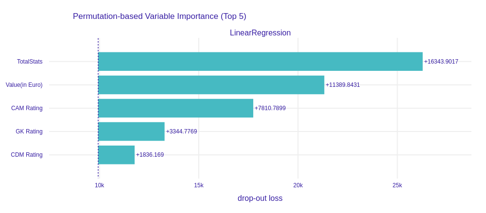

Permutation-based Variable Importance for the log-linear model:

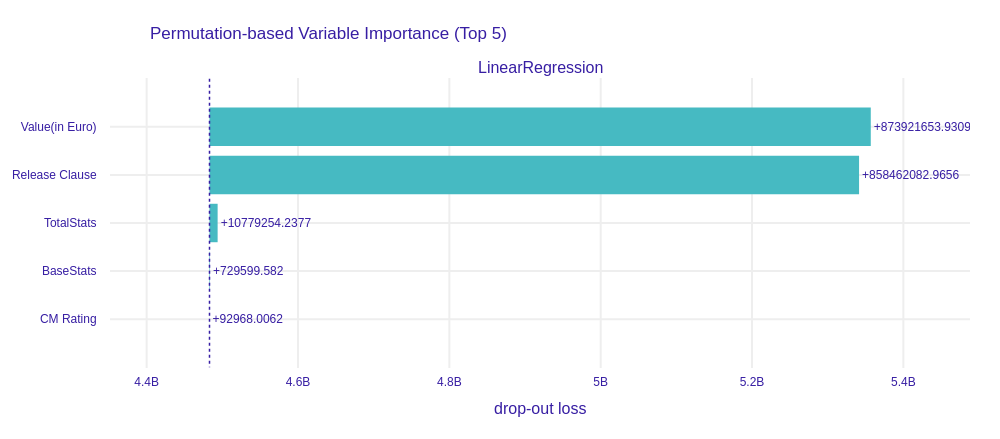

Permutation-based Variable Importance for the smaller (30 trees) forest model:

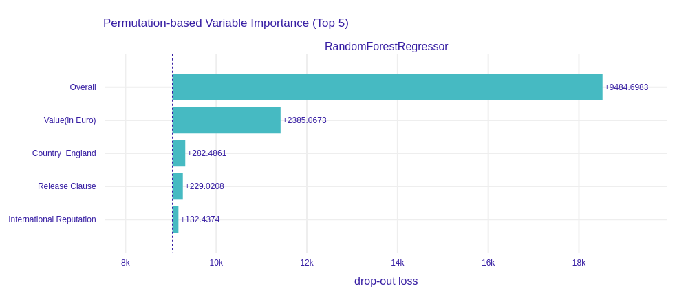

## Comaprison with Gini-based Variable Importance and SHAP-based Variable Importance

We compare 5 most important variables for the forest model according to Permutation-based Variable Importance, Gini-based Variable Importance an SHAP-based Variable Importance. We display a few less important features for the SHAP-based Variable Importance method as truncating the plot to Top 5 was technically a bit tedious.

Explanations between these methods are quite similar - top 4 for Permutation-based and SHAP-based Variable Importance are the same and Gini-based Variable Importance swaps third and forth position (Country_England and Release Clause). The explanations differ on the fifth position - each method suggests different feature (Composure, Reactions, International Reputation). This suggest that the four most important features of the model are quite stable as different methods of explanation does not suggest other features for Top 4, the instability appears for the fifth and further features.

Gini-based Variable Importance for the forest model:

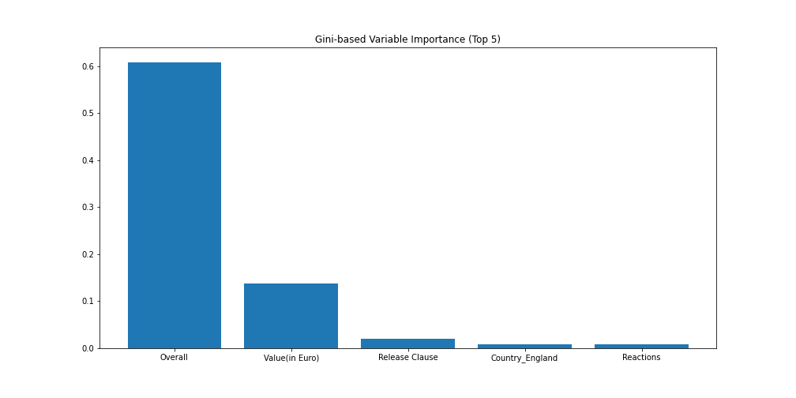

SHAP-based Variable Importance for the forest model:

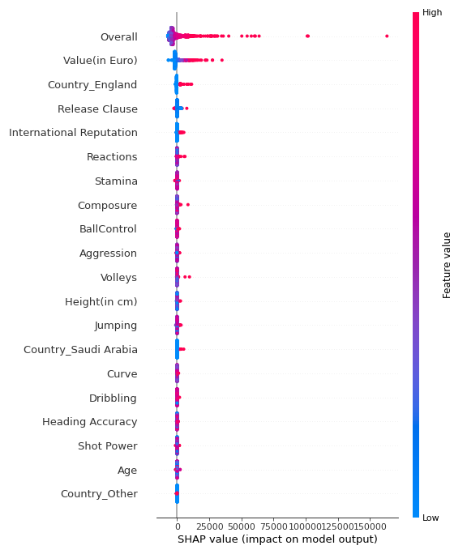

## Summary

We compared PVI for the forest model with Gini-based VI and SHAP-based VI for the same model and with PVI for different models - the linear model, the log-linear model and the smaller forest model.

We observe that the method was quite stable for the tree model - chosen four most important features were consistent with the ones chosen by different VI methods and with chosen by PVI for the smaller forest model.

We also observed that the linear model focuses on different features than the forest models and that the log-linear model combines properties of both approaches which suggests that log transformation of the data is a sensible idea.

# Appendix

## Importing libraries and dataset

```python
# 1. Import libraries

!pip3 install shap
!pip3 install dalex
!pip3 install lime
!pip3 install -q condacolab
import condacolab
condacolab.install()
!conda install -c conda-forge python-kaleido

import pandas as pd
import numpy as np
import matplotlib.pyplot as plt
import plotly
import kaleido

import pickle
import lime
import shap
import dalex as dx
import xgboost

from math import isclose

from sklearn.linear_model import LinearRegression
from sklearn.ensemble import RandomForestRegressor
```

[output not shown]

```python
# 2. Load dataset and models from the previous homework

with open('X_train.pickle', 'rb') as handle:
    X_train_load = pickle.load(handle)

with open('y_train.pickle', 'rb') as handle:
    y_train_load = pickle.load(handle)

with open('X_test.pickle', 'rb') as handle:
    X_test_load = pickle.load(handle)

with open('y_test.pickle', 'rb') as handle:
    y_test_load = pickle.load(handle)

with open('tree_model.pickle', 'rb') as handle:
    forest_reg_load = pickle.load(handle)

with open('linear_model.pickle', 'rb') as handle:
    linear_model_load = pickle.load(handle)

with open('log_linear_model.pickle', 'rb') as handle:
    log_linear_model_load = pickle.load(handle)

with open('different_tree_model.pickle', 'rb') as handle:
    smaller_forest_reg_load = pickle.load(handle)

print(X_train_load)
print(y_train_load)
print(X_test_load)
print(y_train_load)
print(forest_reg_load.predict(X_train_load))
print(linear_model_load.predict(X_train_load))
print(forest_reg_load.predict(X_test_load))
print(linear_model_load.predict(X_test_load))
```

```
       Overall  Potential  Value(in Euro)  Age  Height(in cm)  Weight(in kg)  \
1127        76         77         9000000   27            190             85
6725        68         68         1200000   28            190             87
4966        70         70         1100000   31            190             93
1799        75         75         6000000   22            188             84
4484        70         70         1300000   32            165             63
...        ...        ...             ...  ...            ...            ...
11284       64         64          525000   28            183             83
11964       63         69          700000   23            176             70
5390        69         69          375000   35            187             85
860         77         77        10500000   29            176             73
15795       59         59          220000   29            170             70

       TotalStats  BaseStats  Release Clause  Weak Foot Rating  ...  \
1127         1808        392               0                 3  ...
```

[output cut: 173 more lines]

## Analysys of the model

```python
# 1. Calculate Permutation-based Variable Importance for the forest model (POINT 1)

explainer_forest_dx = dx.Explainer(forest_reg_load, X_test_load, y_test_load, verbose = False)

pvi = explainer_forest_dx.model_parts(random_state = 0)
```

```
X does not have valid feature names, but RandomForestRegressor was fitted with feature names
```

```python
pvi.result
```

|  | variable | dropout_loss | label |
| --- | --- | --- | --- |
| 0 | Jumping | 9082.613490 | RandomForestRegressor |
| 1 | Freekick Accuracy | 9099.315585 | RandomForestRegressor |
| 2 | Crossing | 9111.795156 | RandomForestRegressor |
| 3 | Penalties | 9114.551527 | RandomForestRegressor |
| 4 | Passing Total | 9116.179041 | RandomForestRegressor |
| ... | ... | ... | ... |
| 108 | Release Clause | 9419.337022 | RandomForestRegressor |
| 109 | Country_England | 9460.308206 | RandomForestRegressor |
| 110 | Value(in Euro) | 11066.227314 | RandomForestRegressor |
| 111 | Overall | 18614.076500 | RandomForestRegressor |
| 112 | _baseline_ | 25414.461781 | RandomForestRegressor |

113 rows × 3 columns

```python
fig = pvi.plot(
    max_vars=5,
    digits=4,
    bar_width=40,
    title="Permutation-based Variable Importance (Top 5)",
    show=False
).update_layout(width=1000)

fig.write_image('Point1_im.png')
```

```python
# 2. Calculate Permutation-based Variable Importance for the linear model (POINT 2)

explainer_linear_dx = dx.Explainer(linear_model_load, X_test_load, y_test_load, verbose = False)
pvi_linear = explainer_linear_dx.model_parts(random_state = 0)
```

```python
pvi_linear.result
```

|  | variable | dropout_loss | label |
| --- | --- | --- | --- |
| 0 | Best_Position_CF | 9916.031695 | LinearRegression |
| 1 | Best_Position_LW | 9930.429656 | LinearRegression |
| 2 | Attacking_Work_Rate_Low | 9930.845292 | LinearRegression |
| 3 | Passing Total | 9931.371765 | LinearRegression |
| 4 | Country_Germany | 9932.426704 | LinearRegression |
| ... | ... | ... | ... |
| 108 | GK Rating | 13278.257307 | LinearRegression |
| 109 | CAM Rating | 17744.270322 | LinearRegression |
| 110 | Value(in Euro) | 21323.323466 | LinearRegression |
| 111 | _baseline_ | 24757.546651 | LinearRegression |
| 112 | TotalStats | 26277.382121 | LinearRegression |

113 rows × 3 columns

```python
fig = pvi_linear.plot(
    max_vars=5,
    digits=4,
    bar_width=40,
    title="Permutation-based Variable Importance (Top 5)",
    show=False
).update_layout(width=1000)

fig.write_image('Point2_im_1.png')
```

```python
# 3. Calculate Permutation-based Variable Importance for the log-linear model (POINT 2)

explainer_log_linear_dx = dx.Explainer(log_linear_model_load, X_test_load, y_test_load, verbose = False)
pvi_log_linear = explainer_log_linear_dx.model_parts(random_state = 0)
```

```python
pvi_log_linear.result
```

|  | variable | dropout_loss | label |
| --- | --- | --- | --- |
| 0 | CAM Rating | 4.482690e+09 | LinearRegression |
| 1 | Overall | 4.482706e+09 | LinearRegression |
| 2 | ST Rating | 4.482742e+09 | LinearRegression |
| 3 | CDM Rating | 4.482895e+09 | LinearRegression |
| 4 | RM Rating | 4.482926e+09 | LinearRegression |
| ... | ... | ... | ... |
| 108 | CM Rating | 4.483100e+09 | LinearRegression |
| 109 | BaseStats | 4.483737e+09 | LinearRegression |
| 110 | TotalStats | 4.493786e+09 | LinearRegression |
| 111 | Release Clause | 5.341469e+09 | LinearRegression |
| 112 | Value(in Euro) | 5.356929e+09 | LinearRegression |

113 rows × 3 columns

```python
fig = pvi_log_linear.plot(
    max_vars=5,
    digits=4,
    bar_width=40,
    title="Permutation-based Variable Importance (Top 5)",
    show=False
).update_layout(width=1000)

fig.write_image('Point2_im_2.png')
```

```python
# 4. Calculate Permutation-based Variable Importance for the smaller forest model (POINT 2)

explainer_smaller_forest_dx = dx.Explainer(smaller_forest_reg_load, X_test_load, y_test_load, verbose = False)

pvi_smaller_forest = explainer_smaller_forest_dx.model_parts(random_state = 0)
```

```python
pvi_smaller_forest.result
```

|  | variable | dropout_loss | label |
| --- | --- | --- | --- |
| 0 | Jumping | 8983.961360 | RandomForestRegressor |
| 1 | Sliding Tackle | 8994.217207 | RandomForestRegressor |
| 2 | Long Shots | 8998.981435 | RandomForestRegressor |
| 3 | Pace Total | 8999.510704 | RandomForestRegressor |
| 4 | Passing Total | 9001.178041 | RandomForestRegressor |
| ... | ... | ... | ... |
| 108 | Release Clause | 9264.052484 | RandomForestRegressor |
| 109 | Country_England | 9317.517804 | RandomForestRegressor |
| 110 | Value(in Euro) | 11420.099004 | RandomForestRegressor |
| 111 | Overall | 18519.730062 | RandomForestRegressor |
| 112 | _baseline_ | 25613.484126 | RandomForestRegressor |

113 rows × 3 columns

```python
fig = pvi_smaller_forest.plot(
    max_vars=5,
    digits=4,
    bar_width=40,
    title="Permutation-based Variable Importance (Top 5)",
    show=False
).update_layout(width=1000)

fig.write_image('Point2_im_3.png')
```

```python
# 5. Compare Permutation-based Variable Importance for the forest model with Gini-based Variable Importance and SHAP-based (POINT 3)

forest_reg_load.feature_importances_
```

```
array([6.08635629e-01, 1.86544051e-03, 1.38454301e-01, 5.74745839e-03,
       3.08781652e-03, 3.37697861e-03, 3.12870908e-03, 3.32505547e-03,
       1.95870184e-02, 1.46804365e-03, 1.62601134e-03, 5.70115447e-03,
       2.76159213e-03, 2.64520101e-03, 2.37862531e-03, 2.74774283e-03,
       1.99532018e-03, 3.24299727e-03, 4.07828579e-03, 2.62854456e-03,
       6.66981133e-03, 4.04804910e-03, 6.14388125e-03, 3.80064203e-03,
       3.46297144e-03, 5.06381747e-03, 3.86852590e-03, 4.14052984e-03,
       2.35305624e-03, 3.05441970e-03, 2.52577379e-03, 8.49897632e-03,
       3.37658564e-03, 6.79600675e-03, 6.14327731e-03, 5.59433547e-03,
       3.12049209e-03, 2.97513950e-03, 5.22749862e-03, 2.46409197e-03,
       2.45496384e-03, 2.50568207e-03, 3.34747022e-03, 7.51763863e-03,
       1.93099107e-03, 2.19758673e-03, 3.38149096e-03, 5.23325251e-03,
       3.40530183e-03, 3.70517367e-03, 3.76554791e-03, 4.09856478e-03,
       5.55927265e-03, 9.35187006e-04, 9.16535515e-04, 8.78594867e-04,
       1.21463898e-03, 9.10024441e-04, 2.47600721e-03, 1.39188630e-03,
       1.39161482e-03, 1.56420053e-03, 1.34947374e-03, 1.64838055e-03,
       9.82784072e-04, 1.24785579e-03, 1.18982763e-03, 1.15835659e-03,
       1.60181628e-03, 3.24213975e-04, 2.25751810e-04, 8.60556826e-04,
       3.74191044e-05, 5.66846742e-04, 8.81091548e-03, 6.84190143e-04,
       3.61719611e-04, 5.38288514e-04, 2.37086916e-06, 2.66764560e-04,
       3.56010203e-05, 9.70490492e-04, 4.17208978e-05, 3.03636203e-04,
       2.79612327e-04, 3.87144339e-05, 4.79455056e-04, 7.73756973e-04,
       3.18188283e-04, 6.68848895e-05, 2.29957814e-04, 4.86947661e-05,
       1.42988163e-04, 6.89592284e-04, 1.89795382e-04, 1.01822854e-05,
       1.94265144e-04, 1.80168447e-04, 1.45739275e-04, 2.03309485e-04,
       4.12247362e-04, 1.07428765e-04, 6.98909100e-04, 1.59402084e-04,
       7.88016501e-05, 3.48029471e-04, 6.28659820e-04, 4.24748286e-04,
       3.36650169e-04, 5.40976981e-04, 4.72426435e-04])
```

```python
gini_importances = pd.DataFrame({'variable': X_test_load.columns, 'importance': forest_reg_load.feature_importances_}).sort_values('importance', ascending = False)
gini_importances
```

|  | variable | importance |
| --- | --- | --- |
| 0 | Overall | 0.608636 |
| 2 | Value(in Euro) | 0.138454 |
| 8 | Release Clause | 0.019587 |
| 74 | Country_England | 0.008811 |
| 31 | Reactions | 0.008499 |
| ... | ... | ... |
| 85 | Country_Romania | 0.000039 |
| 72 | Country_China PR | 0.000037 |
| 80 | Country_Norway | 0.000036 |
| 95 | Best_Position_GK | 0.000010 |
| 78 | Country_Korea Republic | 0.000002 |

111 rows × 2 columns

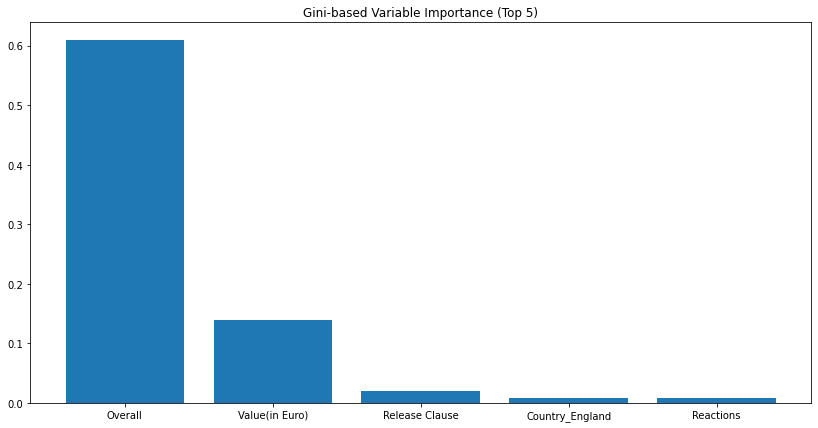

```python
plt.figure(figsize=(14,7))
plt.bar(gini_importances['variable'][:5], gini_importances['importance'][:5])
plt.title("Gini-based Variable Importance (Top 5)")
plt.savefig('Point3_im_1.png')
plt.show()
```

```python
shap_vi = explainer_forest_dx.model_parts(type="shap_wrapper", shap_explainer_type="TreeExplainer")
```

```
100%|===================| 995/1000 [01:49<00:00]
```

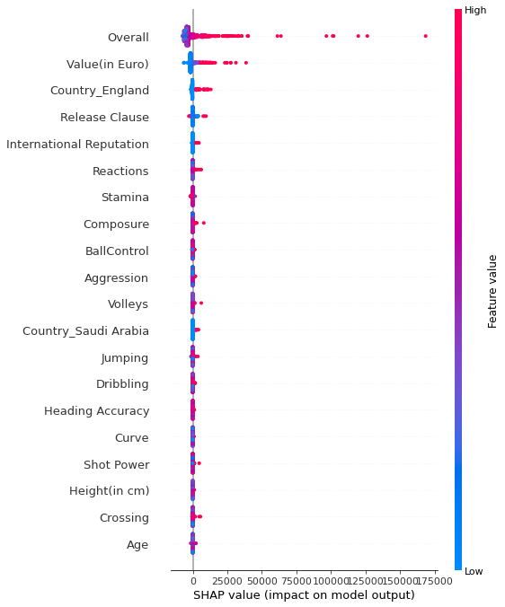

```python
shap_vi.plot(show = False)
plt.savefig('Point3_im_2.png')
```